# Machine Learning Analysis of Gentrification Based on Reddit Data

## 1. Executive Summary

Gentrification is a socioeconomic process that often has a negative effect on vulnerable communities and manifests in ways such as displacement, higher living costs, and physical changes in neighborhoods. Reddit, like all social media platforms, is a place where individuals can discuss their opinions and city subreddits are a common place for residents to vent their frustrations. The goal of this milestone is to gain insight into city subreddits and use machine learning to answer the following two Business Questions:

1. Can we predict the sentiment of city subreddit posts using supervised machine learning models and if so, what features drive sentiment classification?
2. Can we predict what city subreddit a submission post belongs to using supervised machine learning models and if so, what features drive city subreddit classification?

Using SparkML, our team was able to successfully answer these two questions. For Business Question 1, we trained both a Support Vector Machine (SVM) and Random Forest model to identify the sentiment of the subreddit posts. The table below summarizes the final results for both models.

Table 1.1 Model Results for Sentiment Classification

| Model | Accuracy | Precision | Recall | F1 |
| --- | --- | --- | --- | --- |
| SVM | 68% | 62% | 68% | 57% |
| Random Forest | 68% | 65% | 68% | 58% |

The similarity in the metrics shows that both models had similar performance in identifying the sentiments of the subreddit submissions. For Business Question 2, we trained both a Decision Tree and Random Forest model to identify the city subreddit of the subreddit posts. Table 1.2 below summarizes the final results for both models.

| Model | Accuracy | Precision | Recall | F1 |
| --- | --- | --- | --- | --- |
| Decision Tree | 43% | 41% | 43% | 40% |
| Random Forest | 40% | 39% | 40% | 36% |

The model results in Table 1.1 show that we can successfully identify sentiment using a Random Forest model and a SVM model, with the Random Forest performing the best. We also found that features such as the presence of certain keywords, Reddit scoring, and more had a positive effect on the ability to automatically identify sentiment. The model results in Table 1.2, on the other hand, showed that neither the Decision Tree and Random Forest models were adept at predicting subreddit classification. We found that more information was needed to properly identify the subreddits.

## 2. Analysis Report

### 2.1 Sentiment Analysis

#### 2.1.1 Data Preparation

When beginning any machine learning process, the first step in modeling is the data preparation. The first step in our process was reading in our Reddit dataset with posts from the `nyc`, `washingtondc`, `Seattle`, and `Atlanta` subreddits. This dataset already contained the sentiment column that was created using a pre-trained model during the NLP milestone. Our technical goal was to perform binary classification on the Reddit submissions to identify whether the sentiment was positive or negative. Therefore, we removed rows that did not have these two sentiments. While our technical goal in the beginning was to use sentence embeddings and our full dataset, we had to exclude embeddings from our analysis and sample 10% of the original data due to memory and Azure money limitations.

### 2.1.2 Model Preparation

The next step in modeling involved setting up the SparkML pipeline. First, the sentiment label was transformed into binary values using a `StringIndexer`. The tabular features for the classification problem were then identified for modeling:

Next, the tabular features were assembled into vector format using the `VectorAssembler`. The dataset was then split into a train and test dataset using an 80-20 split. Two SparkML models, `LinearSV` and `RandomForestClassifier`, were then initialized and ready for fitting on the training dataset.

#### 2.1.3 Model Execution and Evaluation

Once the data and models were prepared, the models were fit to the training set. The SVM model was trained with a max iteration of 3 and regularization of 0.1 to reduce overfitting. The Random Forest model was trained with 50 decision trees to reduce the variance in the results. Once the models were trained, we analyzed the feature importance, confusion matrices, and evaluated the models using performance metrics. Feature importance is the influence each feature has for the model predictive power. For SVM, this impact is the contribution each feature has on the SVM linear decision boundary. For Random Forest, feature importance is the measure of impact on increasing the purity of the predicted classes within the decision trees. Image 2.1 below shows the feature importance for both models.

Image 2.1 Feature Importance Comparison Between SVM and Random Forest

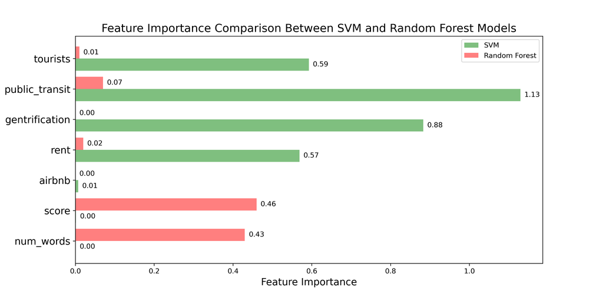

Image 2.1 Feature Importance Comparison Between SVM and Random Forest

The next step of model evaluation consisted of getting the predictions for the testing dataset and comparing them to the labels using a confusion matrix.

Image 2.2 SVM and Random Forest Confusion Test Matrices

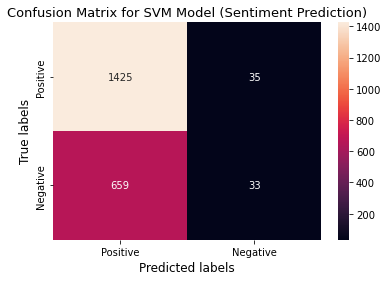

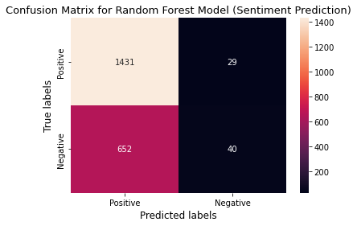

Table 1.1 Test Model Results for Sentiment Classification

| Model | Accuracy | Precision | Recall | F1 |
| --- | --- | --- | --- | --- |
| SVM | 68% | 62% | 68% | 57% |
| Random Forest | 68% | 65% | 68% | 58% |

The comparison of SVM and Random Forest models for sentiment prediction shows that both models exhibit similar accuracy at 68%, suggesting an equal proportion of correct predictions for sentiment classification. However, the Random Forest slightly surpasses the SVM in discriminative power, as indicated by a higher F1 score.

### 2.2 Subreddit Classification

#### 2.2.1 Data Preparation

Similar to the data preparation for data analysis, we started with the raw data from each of our subreddits. We then removed rows that did not contain any text in the posts. We chose to keep posts which were indicated as removed or deleted by Reddit, since they still contained feature data. We ended up subsetting to only the columns that were integer or float, that were majority populated. We then applied a universal sentence embedder to the post text, but then ran into memory constraints. In order to solve those issues, we sampled 10% of the original data.

#### 2.2.2 Model Preparation

The next step in modeling involved setting up the SparkML pipeline. First, the subreddit labels were transformed into numerical values using a `StringIndexer`, and then they were converted into one hot encodings in order to remove any hierarchical value from the labels. The tabular features for the classification problem were then identified for modeling:

1. `num_words`: Number of words in submission post
2. `num_comments`: Number of comments on submission post
3. `score`: Reddit score
4. `airbnb`: Airbnb keyword boolean
5. `rent`: Rent keyword boolean
6. `gentrification`: Gentrification keyword boolean
7. `public_transit`: Public transit keyword boolean

Next, the tabular features were assembled into vector format using the `VectorAssembler`. The dataset was then split into a train and test dataset using an 80-20 split. Two SparkML models, `DecisionTree` and `RandomForestClassifier`, were then initialized and ready for fitting on the training dataset. We chose these two models in order to see whether we’d be able to gain more predictive power by using an ensemble method, since a Random Forest model is an ensemble of decision trees.

#### 2.2.3 Model Execution and Evaluation

Once the data and models were prepared, the models were fit to the training set. The Decision Tree model utilized a single decision tree to make the classifications. The Random Forest model, on the other hand, was trained with 20 decision trees to reduce the variance in the results. Once the models were trained, we again analyzed the feature importance, confusion matrices, and evaluated the models using performance metrics. Image 2.1 below shows the feature importance for both the Decision Tree and Random Forest model.

Image 2.1 Feature Importance Comparison Between Decision Tree and Random Forest

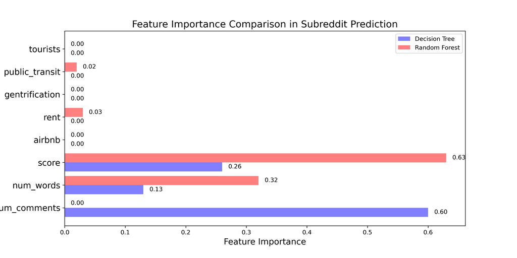

Image 2.2 Decision Tree and Random Forest Confusion Test Matrices

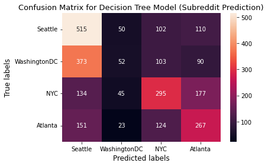

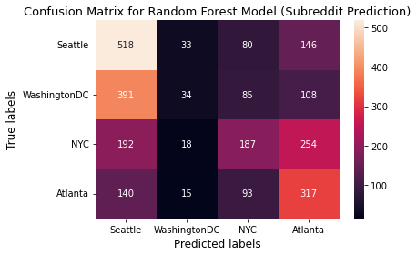

Table 2.1 Test Model Results for Subreddit Classification

| Model | Accuracy | Precision | Recall | F1 |
| --- | --- | --- | --- | --- |
| Decision Tree | 43% | 41% | 43% | 40% |
| Random Forest | 40% | 39% | 40% | 36% |

The Decision Tree model outperforms the Random Forest model across all reported metrics, albeit by a small margin. This suggests that for this particular task, with the given features and dataset, the simpler Decision Tree model is slightly better suited than the more complex Random Forest model. However, the overall performance of both models is quite similar and relatively low, indicating either a challenging classification problem or that there may be room for improvement in model selection, feature engineering, or parameter tuning.

## 3. Conclusion

#### Links to Notebooks

SparkML Notebook: [here](https://github.com/gu-dsan6000/fall-2023-reddit-project-team-02/blob/main/code/wip_scripts/ML_Milestone-metrics.ipynb).

Machine Learning Visualizations: [here](https://github.com/gu-dsan6000/fall-2023-reddit-project-team-02/blob/main/code/wip_scripts/ml_plots.ipynb)